# p8105_hw5_sy3269

Soomin You

## Problem 1

For n people in a room, we will check for any duplicate birthdays. Some of the assumptions we make are as follows:

1. there are at least two people share the same birthday
2. there are no leap years
3. birthdays are uniformly distributed over the year

```r
bday_sim = function(n) {

  bdays = sample(1:365, size = n, replace = TRUE)

  duplicate = length(unique(bdays)) < n

  return(duplicate)

}
```

If the simulation is ran 10,000 times for each group size between 2 and 50, we get the following function.

```r
sim_res =
  expand_grid(
    n = 2:50,
    iter = 1:10000
  ) |>
  mutate(res = map_lgl(n, bday_sim)) |>
  group_by(n) |>
  summarize(prob = mean(res))
```

The probability that at least two people in the group share a birthday is averaged across the 10000 simulation runs and the probability as a function of group size was plotted. If we have about 23 people, there is a 0.5 probability of at least two people sharing the same birthday.

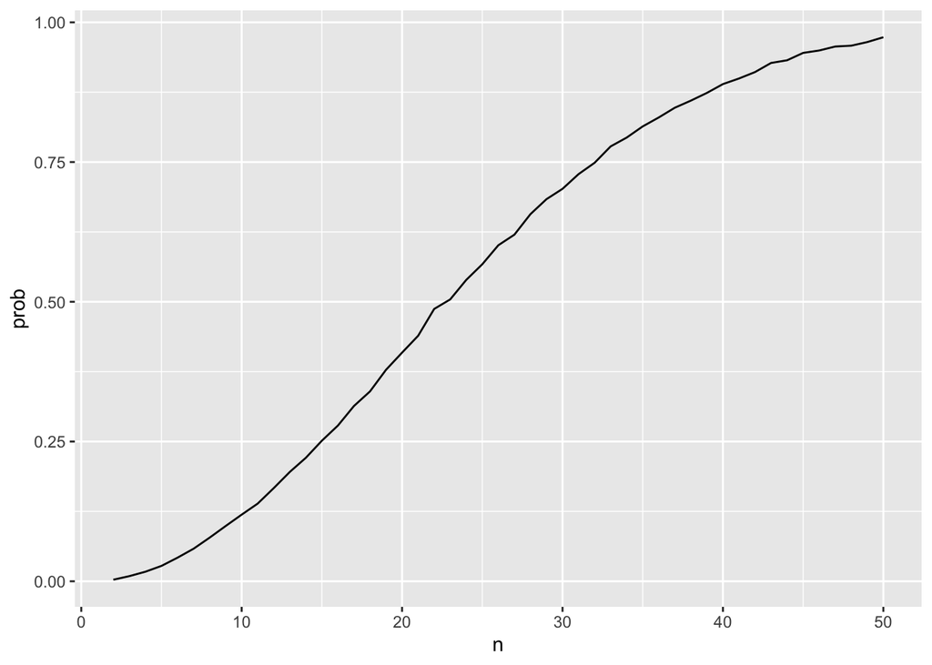

```r
sim_res |>
  ggplot(aes(x = n, y = prob )) +
  geom_line()
```